# STAT 413/613 HW 1

Ifebunandu Jerome Okeke

2021-01-28

# Instructions

Admin elements:  
1. Upload a photo (headshot) of yourself into your canvas profile  
2. Review the Syllabus and the [academic integrity code](https://www.american.edu/policies/students/upload/academic-integrity-code-2020.pdf).  
3. Fill in your information in the Student Info spreadsheet under the Canvas Collaboration site.

Analysis Elements: Rename the starter file under the analysis directory as `hw_01_yourname.Rmd` and use it for your solutions.  
1. Modify the “author” field in the YAML header.  
2. Stage and Commit R Markdown and HTML files (no PDF files).  
3. **Push both .Rmd and HTML files to GitHub**.  
- Make sure you have knitted to HTML prior to staging, committing, and pushing your final submission.  
4. **Commit each time you answer a part of question, e.g. 1.1**  
5. **Push to GitHub after each major question**, e.g., College Scorecard and World Bank Data  
- **Committing and Pushing are graded elements for this homework.**  
6. When complete, submit a response in Canvas that you have completed the homework. No need to submit your files.

- Only include necessary code to answer the questions.
- Most of the functions you use should be from the tidyverse. Too much base R will result in point deductions.
- Use Pull requests and or email to ask me any questions. If you email, ensure your most recent code is pushed to GitHub whether it is working or not.

# Learning Outcomes:

- Operate with Git and GitHub.
- Apply concepts and methods from STAT 412/612.

# 1 Canvas Picture, Syllabus, and Student Info

Review the Syllabus on Canvas and answer the following questions:

I, *Ifebunandu Okeke* have:

1. Added a photo of myself (headshot) to my Canvas profile
2. Reviewed the syllabus and the associated policies on the following date: 01/25/2021
3. Reviewed the American University policies on academic integrity, and understand how they apply to this course and agree to comply with them for this course
4. Filled in my information in the Student Info spreadsheet on Canvas collaborations

# 2 College Scorecard

The data folder contains “college_score_200601.csv”, a subset of the data in the [College Scorecard](https://collegescorecard.ed.gov/data/) database as of June 1, 2020. These data contain information on colleges in the United States. The variables include:

- `UNITID` and `OPEID`: Identifiers for the colleges.
- `INSTNM`: Institution name
- `ADM_RATE`: The Admission Rate.
- `SAT_AVE`: Average SAT equivalent score of students admitted.
- `UGDS`: Enrollment of undergraduate certificate/degree-seeking students
- `COSTT4_A`: Average cost of attendance (academic year institutions)
- `AVGFACSAL`: Average faculty salary
- `GRAD_DEBT_MDN`: The median debt for students who have completed
- `AGE_ENTRY`: Average age of entry
- `ICLEVEL`: Level of institution (1 = 4-year, 2 = 2-year, 3 = less than 2-year).
- `MN_EARN_WNE_P10`: Mean earnings of students working and not enrolled 10 years after entry.
- `MD_EARN_WNE_P10`: Median earnings of students working and not enrolled 10 years after entry.
- `FEMALE`: Share of female students
- `PCT_WHITE`: Percent of the population from students’ zip codes that is White, via Census data

```r
library(tidyverse)
C_score <- read_csv(file = "./../data/college_score_200601.csv")
```

# 3 2.1. If you used the default settings for reading in the data, 11 variables are probably type character when they should be numeric.

Which ones?

# 4 Solution:

They 11 variables are :

MN_EARN_WNE_P10 MD_EARN_WNE_P10 SAT_AVG ADM_RATE UGDS COSTT4_A AVGFACSAL GRAD_DEBT_MDN AGE_ENTRY FEMALE PCT_WHITE

# 5 2.2. Why were they read in as type character?

They are were incorrectly read as character because some of the missing data are labeled as " Null and privacy suppressed"

# 6 3. Use a readr function to fix these variables to be numeric and save the updated tibble.

Solution:

```r
C_score %>%

  mutate(MN_EARN_WNE_P10 = parse_number(MN_EARN_WNE_P10),
         MD_EARN_WNE_P10 = parse_number(MD_EARN_WNE_P10),
         SAT_AVG  = parse_number(SAT_AVG ),
         ADM_RATE = parse_number(ADM_RATE),
         UGDS = parse_number(UGDS),
         COSTT4_A = parse_number(COSTT4_A),
         AVGFACSAL= parse_number(AVGFACSAL),
         GRAD_DEBT_MDN= parse_number(GRAD_DEBT_MDN),
         AGE_ENTRY = parse_number(AGE_ENTRY),
         FEMALE = parse_number(FEMALE),
         PCT_WHITE = parse_number(PCT_WHITE)) ->

  C_score
```

4. How is average faculty salary associated the mean earnings of students ten years after initial enrollment? Create an appropriate plot and interpret the plot to justify your answer.

# 7 solution

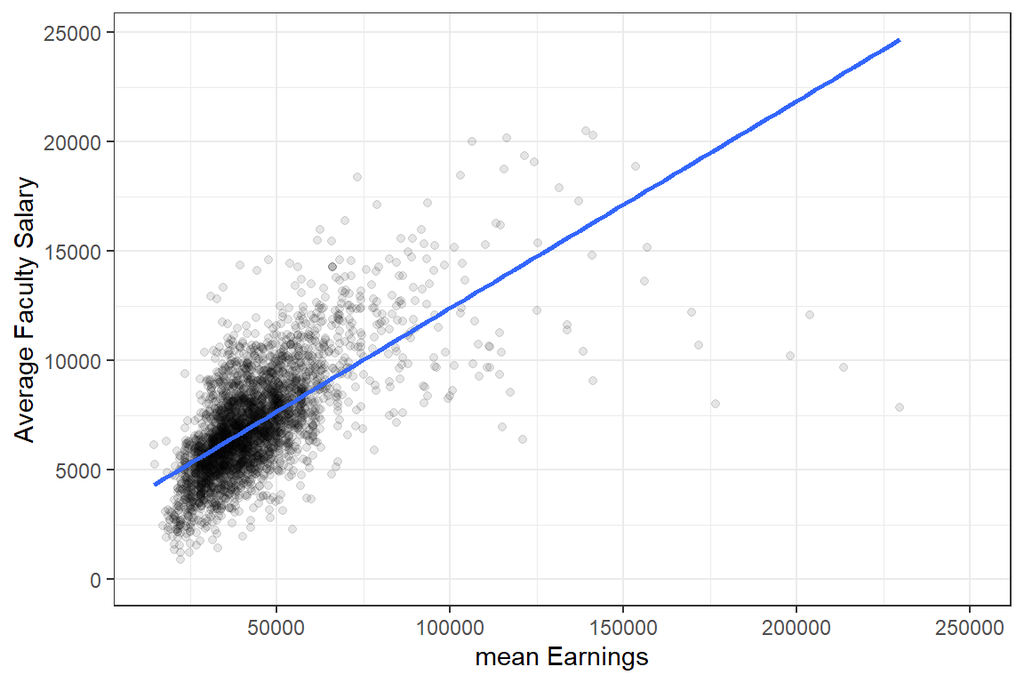

```r
C_score %>%
  ggplot(aes(x = MN_EARN_WNE_P10, y = AVGFACSAL)) +
  geom_point(alpha = 0.1) +
  geom_smooth(method = lm, se = FALSE) +
  theme_bw() +
  xlab("mean Earnings") +
  ylab("Average Faculty Salary")
```

_ The data shows that most faculty staffs earn an average salary of between $4,000 - $10,000 and just vey few of the faculty staffs earn very high income.

5. Does the level of the institution seem to be associated with the mean earnings of students ten years after enrollment? Reproduce this plot in R to explore this relationship and interpret the plot:

# 8 solution

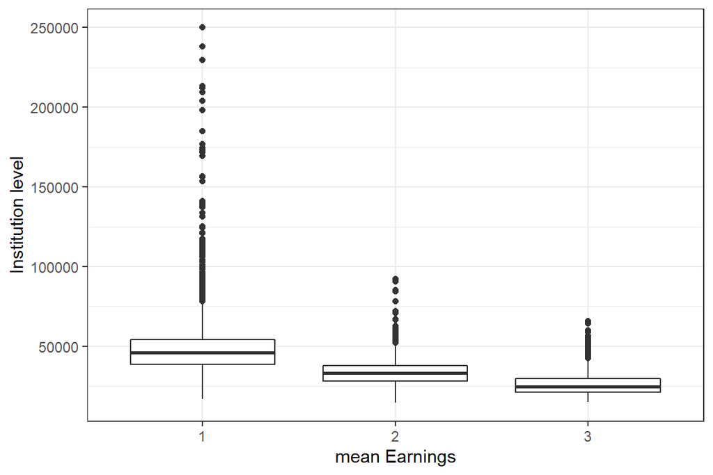

```r
C_score %>%
  select(ICLEVEL, MN_EARN_WNE_P10) %>%
  filter(!is.na(ICLEVEL), !is.na(MN_EARN_WNE_P10)) %>%
  mutate(ICLEVEL = as.factor(ICLEVEL)) %>%
  ggplot(aes(x = ICLEVEL, y = MN_EARN_WNE_P10)) +
  geom_boxplot() +
  theme_bw() +
  xlab("mean Earnings") +
  ylab("Institution level")
```

- Yes the level of the institution does seem to be associated with the mean earnings of students ten years after enrollment because of the different median value for each institution level.

6. Plot the mean earnings 10 years after enrollment for level 1 institutions as the Y axis against PCT_WHITE and, in a second plot, against FEMALE.

# 9 solution 6.1(a)

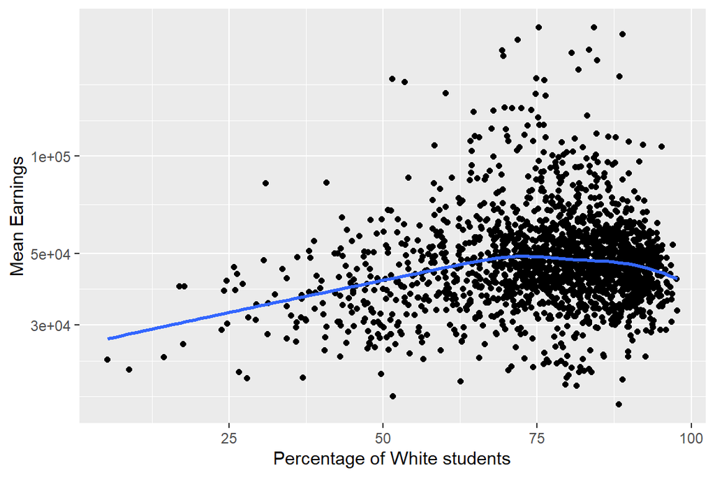

```r
C_score %>%
  select(ICLEVEL, MN_EARN_WNE_P10, PCT_WHITE) %>%
  filter(!is.na(ICLEVEL),
         !is.na(MN_EARN_WNE_P10),
         !is.na(PCT_WHITE),
         ICLEVEL == 1) %>%
  ggplot(mapping = aes(x = PCT_WHITE, y = MN_EARN_WNE_P10)) +
  geom_point() +
  scale_y_log10() +
  geom_smooth(method = "loess", se = FALSE) +
  xlab("Percentage of White students") +
  ylab("Mean Earnings")
```

# 10 6.1(b)

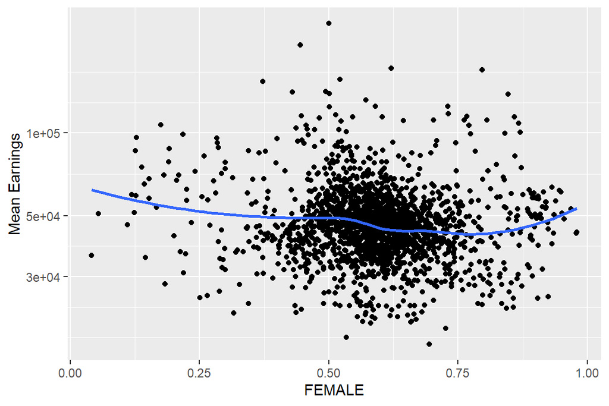

```r
C_score %>%
  select(ICLEVEL, MN_EARN_WNE_P10, FEMALE) %>%
  filter(!is.na(ICLEVEL),
         !is.na(MN_EARN_WNE_P10),
         !is.na(FEMALE),
         ICLEVEL == 1) %>%
  ggplot(mapping = aes(x = FEMALE, y = MN_EARN_WNE_P10)) +
  geom_point() +
  scale_y_log10() +
  geom_smooth(method = "loess", se = FALSE) +
  xlab("FEMALE") +
  ylab("Mean Earnings")
```